# Video Game Sales and Performance Analysis - Group 6

```r
games<-read.csv('Video games sales.csv')
```

```r
games$Platform<-as.factor(games$Platform)
games$Year_of_Release<-as.factor(games$Year_of_Release)
games$Genre<-as.factor(games$Genre)
games$Publisher<-as.factor(games$Publisher)
games$Developer<-as.factor(games$Developer)
games$Rating<-as.factor(games$Rating)
```

```r
games<-na.omit(games)

#unique(games$Rating)

games$Rating <- ifelse( games$Rating== "", NA,games$Rating )
#unique(games$Rating)

games<-subset(games,games$Rating!="NA")
games<-subset(games,games$Year_of_Release!="N/A")
#nrow(games)

library(ezids)
games_final= outlierKD2(games,Global_Sales,rm=TRUE,hist=FALSE)
```

```
## Outliers successfully removed
```

```r
games_final<-na.omit(games_final)
```

# 1 Introduction

## 1.1 Objective

This research project’s goal is to continue to explore multivariate relationships in the data and leverage machine learning models to predict a game’s success based on its characteristics. At the end of our project, we hope to answer the question of “What makes a game successful?”

## 1.2 Data Source

The dataset used for this report was sourced through web scraping from Metacritic. It is important to note that certain observations are missing, as Metacritic covers only a subset of the gaming platforms. As a result, some games may not have complete information for all the variables. However, the dataset contains approximately 6,900 complete cases.

The dataset has information on the following attributes:

**Game Specific:**

Name: The name of the video game

Genre: The genre of the video game

Platform: The platform(s) on which the video game was released

Developer: The developer of the video game

Publisher: The publisher of the video game

Year of Release: The year in which the video game was released

**Scores:**

Metacritic User Score: The score given to the game by users.

Metacritic Critic Score: The score given to the game by critics.

**Sales:**

North America: The number of units sold in North America

Europe: The number of units sold in Europe

Japan: The number of units sold in Japan

Global: The total number of units sold worldwide

# 2 Exploratory Data Analysis

## 2.2 Single Platform vs Multi Platform comparison

As part of our research questions, we wanted to analyze how games performed when they were targeted towards a specific platform vs when they are released across multiple platforms.

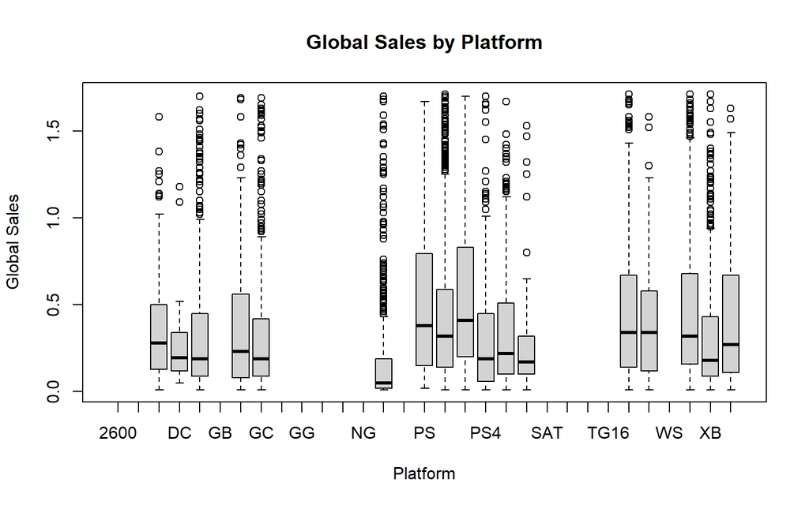

```r
library(dplyr)
library(ezids)
library(ggplot2)

grouped_by_platform <- split(games_final, games_final$Platform)
platform_summary <- lapply(grouped_by_platform, function(x) summary(x$Global_Sales))
boxplot(Global_Sales ~ Platform, data = games_final, main="Global Sales by Platform", xlab="Platform", ylab="Global Sales")
```

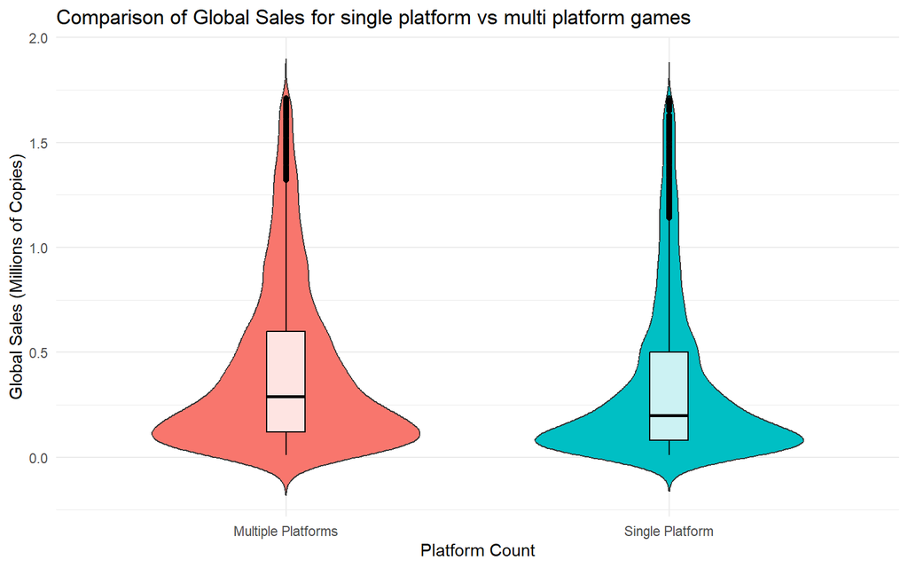

```r
games_final <- games_final %>%
  group_by(Name) %>%
  mutate(Platform_Count = n())

single_platform_games <- filter(games_final, Platform_Count == 1)
multiple_platform_games <- filter(games_final, Platform_Count > 1)


average_sales_single_platform <- mean(single_platform_games$Global_Sales)
average_sales_multiple_platforms <- mean(multiple_platform_games$Global_Sales)

average_rating_single_platform <- mean(single_platform_games$Critic_Score, na.rm = TRUE)
average_rating_multiple_platforms <- mean(multiple_platform_games$Critic_Score, na.rm = TRUE)

#cat("Average Sales - Single Platform Games:", average_sales_single_platform, "\n")
#cat("Average Sales - Multiple Platform Games:", average_sales_multiple_platforms, "\n\n")

#cat("Average Rating - Single Platform Games:", average_rating_single_platform, "\n")
#cat("Average Rating - Multiple Platform Games:", average_rating_multiple_platforms, "\n")


t_test_result <- t.test(single_platform_games$Global_Sales, multiple_platform_games$Global_Sales)

# Extract p-value
p_value_t_test <- t_test_result$p.value

# Display p-value
#cat("P-value (t-test):", p_value_t_test, "\n")


combined_data <- rbind(data.frame(Sales = single_platform_games$Global_Sales, Platform = "Single Platform"),
                       data.frame(Sales = multiple_platform_games$Global_Sales, Platform = "Multiple Platforms"))

# Global Sales

ggplot(combined_data, aes(x = Platform, y = Sales, fill = Platform)) +
  geom_violin(trim = FALSE, scale = "width", width = 0.7) +
  geom_boxplot(width = 0.1, fill = "white", color = "black", alpha = 0.8) +
  theme_minimal() +
  labs(title = "Comparison of Global Sales for single platform vs multi platform games",
       x = "Platform Count",
       y = "Global Sales (Millions of Copies)") +
  theme(legend.position = "none")
```

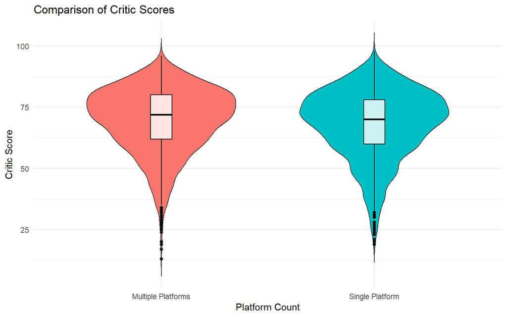

```r
# Critic Score
combined_data <- rbind(data.frame(Score = single_platform_games$Critic_Score, Platform = "Single Platform"),
                       data.frame(Score = multiple_platform_games$Critic_Score, Platform = "Multiple Platforms"))


ggplot(combined_data, aes(x = Platform, y = Score, fill = Platform)) +
  geom_violin(trim = FALSE, scale = "width", width = 0.7) +
  geom_boxplot(width = 0.1, fill = "white", color = "black", alpha = 0.8) +
  theme_minimal() +
  labs(title = "Comparison of Critic Scores",
       x = "Platform Count",
       y = "Critic Score") +
  theme(legend.position = "none")
```

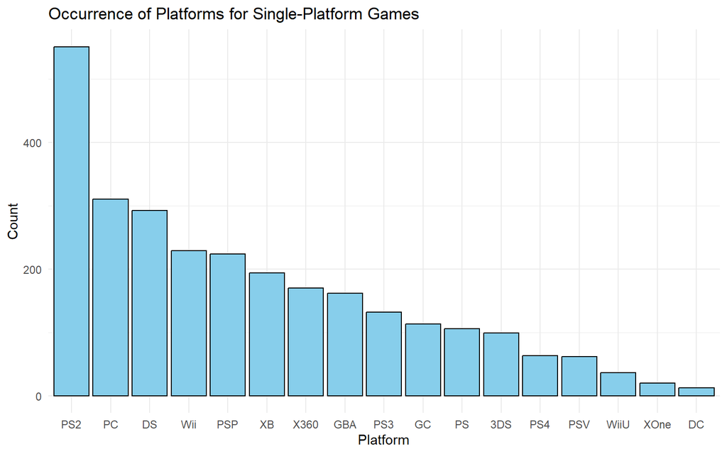

```r
# For single platform games

platform_occurrence <- single_platform_games %>%
  group_by(Platform) %>%
  summarise(Count = n()) %>%
  arrange(desc(Count))

ggplot(platform_occurrence, aes(x = reorder(Platform, -Count), y = Count)) +
  geom_bar(stat = "identity", fill = "skyblue", color = "black") +
  labs(title = "Occurrence of Platforms for Single-Platform Games",
       x = "Platform",
       y = "Count") +
  theme_minimal()
```

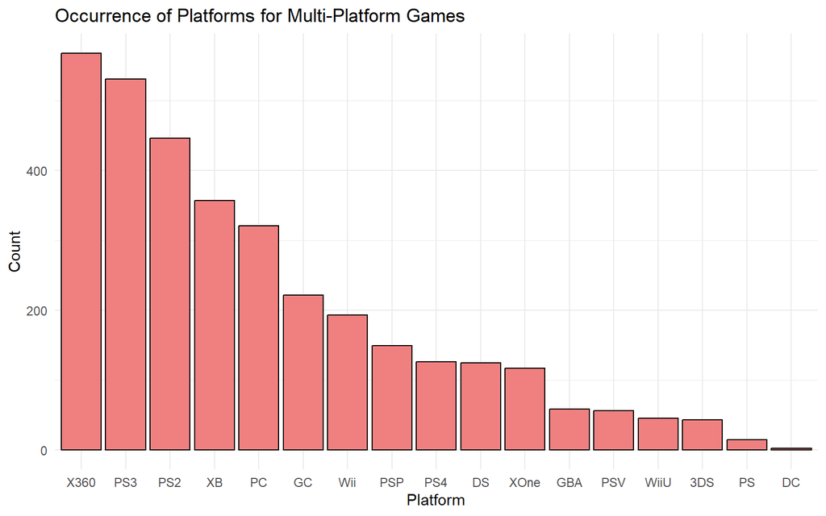

```r
# For multi platform games

platform_occurrence_multi <- multiple_platform_games %>%
  group_by(Platform) %>%
  summarise(Count = n()) %>%
  arrange(desc(Count))

ggplot(platform_occurrence_multi, aes(x = reorder(Platform, -Count), y = Count)) +
  geom_bar(stat = "identity", fill = "lightcoral", color = "black") +
  labs(title = "Occurrence of Platforms for Multi-Platform Games",
       x = "Platform",
       y = "Count") +
  theme_minimal()
```

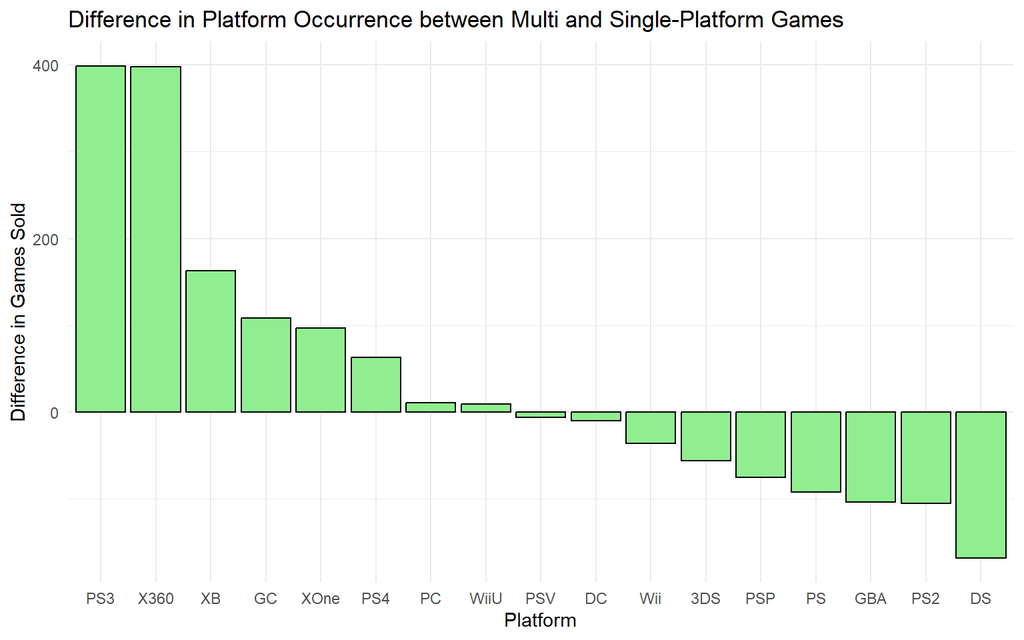

```r
platform_difference <- merge(platform_occurrence, platform_occurrence_multi, by = "Platform", suffixes = c("_Single", "_Multi"))
platform_difference$Difference <- platform_difference$Count_Multi - platform_difference$Count_Single

ggplot(platform_difference, aes(x = reorder(Platform, -Difference), y = Difference)) +
  geom_bar(stat = "identity", fill = "lightgreen", color = "black") +
  labs(title = "Difference in Platform Occurrence between Multi and Single-Platform Games",
       x = "Platform",
       y = "Difference in Games Sold") +
  theme_minimal()
```

## 2.3 Genre and Developer vs Global Sales

We aimed to explore the significant factors influencing game sales, particularly focusing on the impact of the game’s genre and developer. To analyze this, we generated a scatter plot visualizing the global sales of the top 20 developers, with each point color-coded based on the corresponding game’s genre.

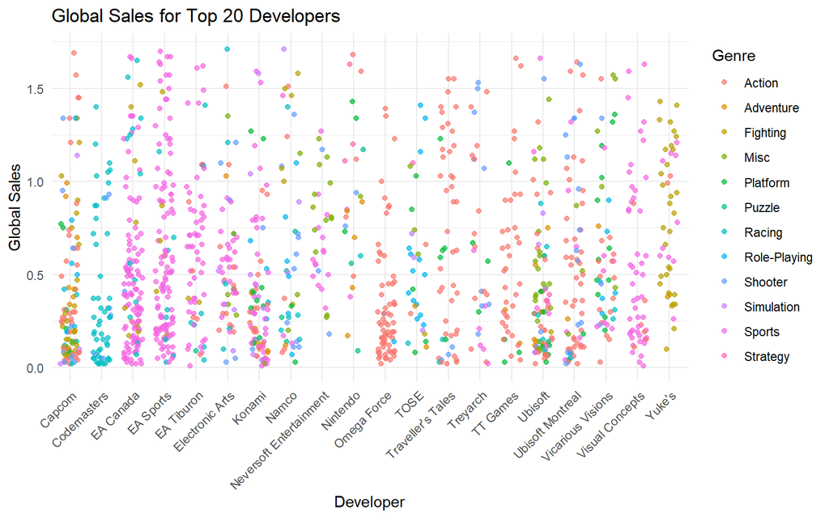

```r
data=games_final

top_developers <- data %>%
  group_by(Developer) %>%
  summarise(Total_Sales = sum(Global_Sales, na.rm = TRUE)) %>%
  top_n(20, Total_Sales) %>%
  pull(Developer)

filtered_data <- data %>%
  filter(Developer %in% top_developers)

ggplot(filtered_data, aes(x = Developer, y = Global_Sales, color = Genre)) +
  geom_point(position = position_jitter(width = 0.3, height = 0), alpha = 0.7) +
  labs(title = "Global Sales for Top 20 Developers",
       x = "Developer",
       y = "Global Sales") +
  theme_minimal() +
  theme(axis.text.x = element_text(angle = 45, hjust = 1))
```

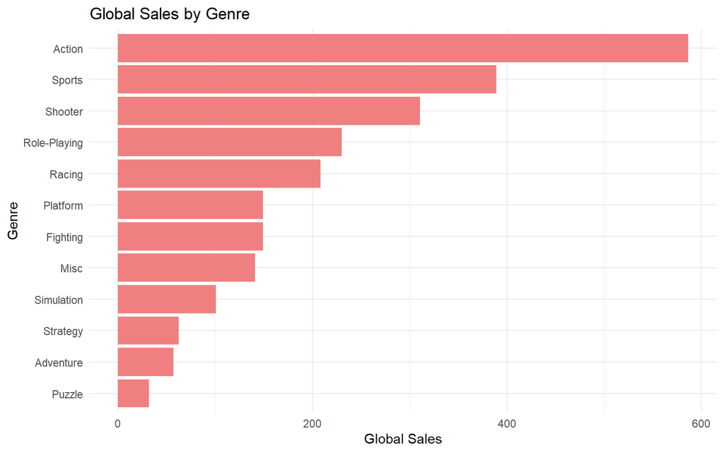

```r
data$Genre <- factor(data$Genre, levels = names(sort(tapply(data$Global_Sales, data$Genre, sum), decreasing = FALSE)))

ggplot(data, aes(x = Genre, y = Global_Sales)) +
  geom_bar(stat = "identity", fill = "lightcoral") +
  coord_flip() +
  labs(title = "Global Sales by Genre",
       x = "Genre",
       y = "Global Sales") + theme_minimal()
```

## 2.4 Yearly Sales by Region and Genre

Continuing our investigation, we looked to dive into the trends of annual video game sales across different regions. Our objective is to unravel the dynamic patterns and shifts in the popularity of video game genres over time. By visualizing the data on a yearly basis, we aim to discern evolving consumer preferences, identify emerging trends, and gain insights into the changing landscape of the gaming industry. This exploration will provide valuable context for understanding the trajectory of video game sales in distinct regions and shed light on the trends that have shaped the market’s evolution.

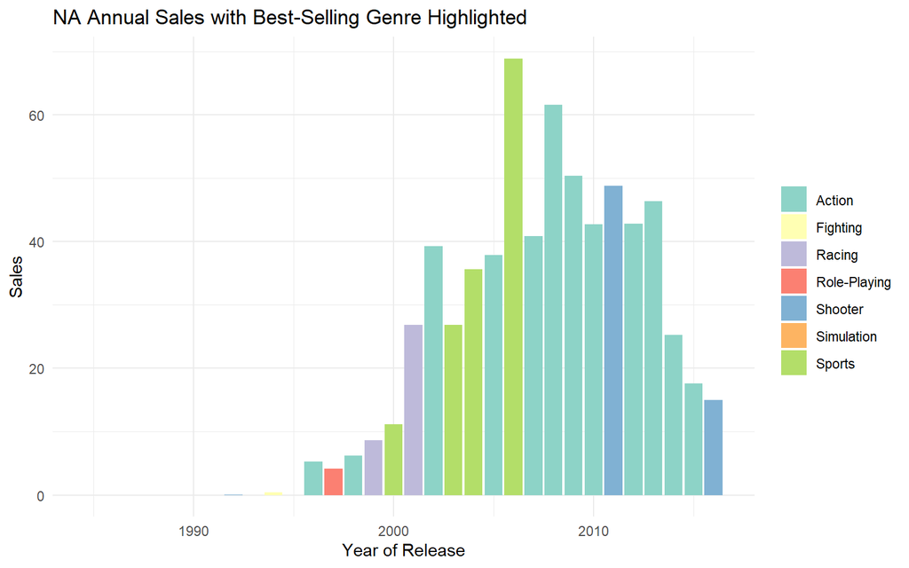

```r
library(dplyr)
library(ggplot2)
library(tidyr)
library(ggrepel)
games$Year_of_Release <- as.numeric(as.character(games$Year_of_Release))

na_sales <- games %>%
  group_by(Year_of_Release, Genre) %>%
  summarise(NA_Sales = sum(NA_Sales, na.rm = TRUE)) %>%
  ungroup()
na_best_selling_genres <- na_sales %>%
  arrange(desc(NA_Sales)) %>%
  group_by(Year_of_Release) %>%
  slice(1) %>%
  ungroup()

# Create a bar plot for NA region only with each genre a different color
na_genre_sales_plot <- ggplot(na_best_selling_genres, aes(x = Year_of_Release, y = NA_Sales, fill = Genre)) +
  geom_bar(stat = "identity", position = "dodge") +
  theme_minimal() +
  scale_fill_brewer(palette = "Set3") +
  labs(title = "NA Annual Sales with Best-Selling Genre Highlighted", x = "Year of Release", y = "Sales") +
  theme(legend.title = element_blank())

print(na_genre_sales_plot)
```

The graph displays the annual sales of the best-selling video game genres in North America, with each bar representing a specific year.

- A period dominated by action games might be followed by a surge in the popularity of sports games.

# 3 Critic_Score Vs Sales

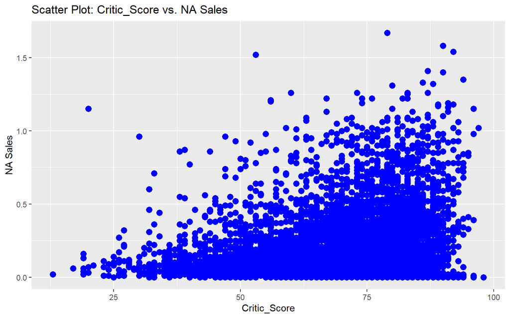

```r
library(ggplot2)

ggplot(games_final, aes(x = Critic_Score, y = NA_Sales)) +
  geom_point(color = "blue", size = 3) +
  labs(title = "Scatter Plot: Critic_Score vs. NA Sales",
       x = "Critic_Score",
       y = "NA Sales")
```

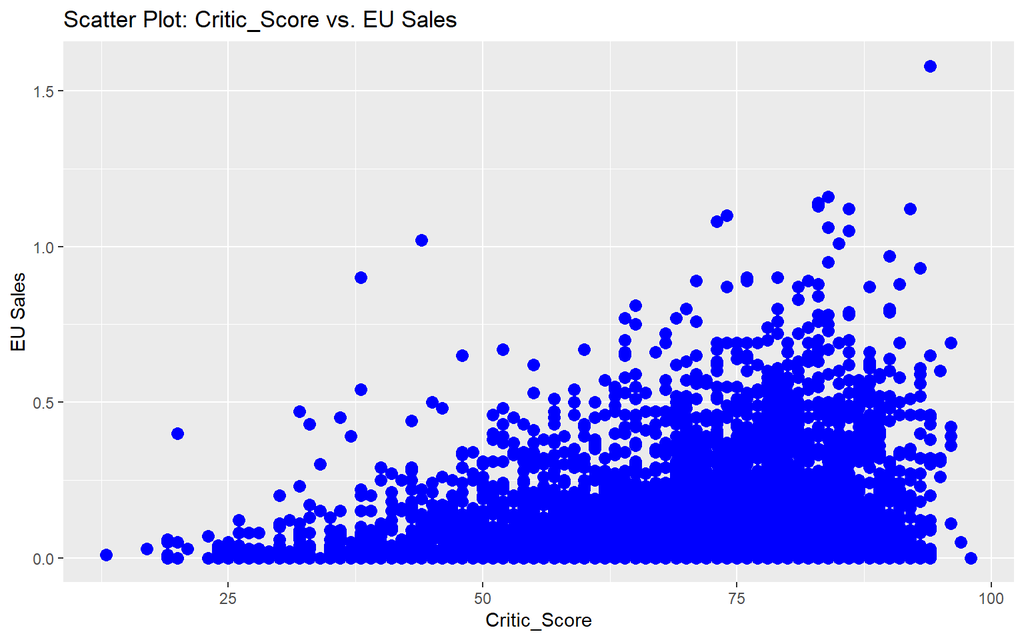

```r
ggplot(games_final, aes(x = Critic_Score, y = EU_Sales)) +
  geom_point(color = "blue", size = 3) +
  labs(title = "Scatter Plot: Critic_Score vs. EU Sales",
       x = "Critic_Score",
       y = "EU Sales")
```

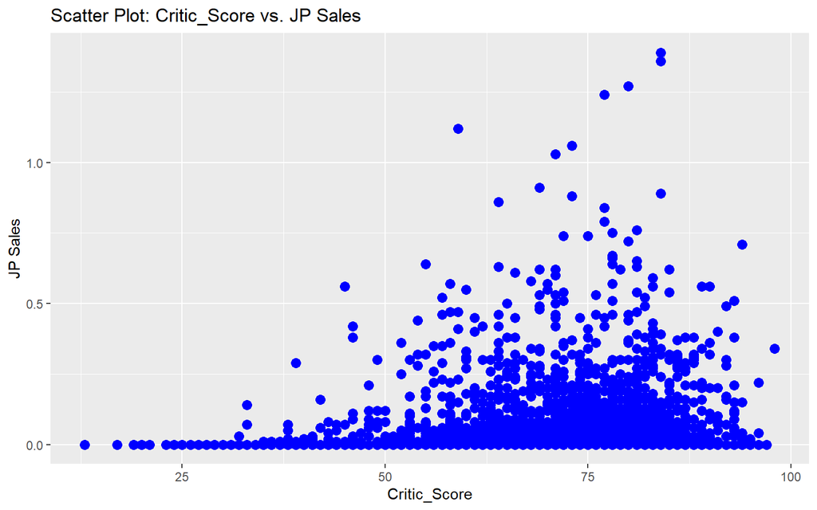

```r
ggplot(games_final, aes(x = Critic_Score, y = JP_Sales)) +
  geom_point(color = "blue", size = 3) +
  labs(title = "Scatter Plot: Critic_Score vs. JP Sales",
       x = "Critic_Score",
       y = "JP Sales")
```

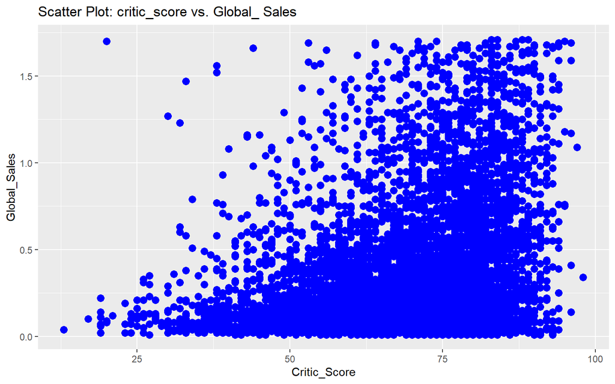

```r
ggplot(games_final, aes(x = Critic_Score, y =Global_Sales)) +
  geom_point(color = "blue", size = 3) +
  labs(title = "Scatter Plot: critic_score vs. Global_ Sales",
       x = "Critic_Score",
       y = "Global_Sales")
```

# 4 Model Building

## 4.1 The Regression problem

Our initial approach involves developing predictive models that quantify global sales as a numeric value.

### 4.1.1 Linear Model

```r
games<-read.csv('Video games sales.csv')
str(games)
```

```
## 'data.frame':    16719 obs. of  16 variables:
##  $ Name           : chr  "Wii Sports" "Super Mario Bros." "Mario Kart Wii" "Wii Sports Resort" ...
##  $ Platform       : chr  "Wii" "NES" "Wii" "Wii" ...
##  $ Year_of_Release: chr  "2006" "1985" "2008" "2009" ...
##  $ Genre          : chr  "Sports" "Platform" "Racing" "Sports" ...
##  $ Publisher      : chr  "Nintendo" "Nintendo" "Nintendo" "Nintendo" ...
##  $ NA_Sales       : num  41.4 29.1 15.7 15.6 11.3 ...
##  $ EU_Sales       : num  28.96 3.58 12.76 10.93 8.89 ...
##  $ JP_Sales       : num  3.77 6.81 3.79 3.28 10.22 ...
##  $ Other_Sales    : num  8.45 0.77 3.29 2.95 1 0.58 2.88 2.84 2.24 0.47 ...
##  $ Global_Sales   : num  82.5 40.2 35.5 32.8 31.4 ...
##  $ Critic_Score   : int  76 NA 82 80 NA NA 89 58 87 NA ...
##  $ Critic_Count   : int  51 NA 73 73 NA NA 65 41 80 NA ...
##  $ User_Score     : num  8 NA 8.3 8 NA NA 8.5 6.6 8.4 NA ...
##  $ User_Count     : int  322 NA 709 192 NA NA 431 129 594 NA ...
##  $ Developer      : chr  "Nintendo" "" "Nintendo" "Nintendo" ...
##  $ Rating         : chr  "E" "" "E" "E" ...
```

```r
games$Platform<-as.factor(games$Platform)
games$Year_of_Release<-as.numeric(games$Year_of_Release)
games$Genre<-as.factor(games$Genre)
games$Publisher<-as.factor(games$Publisher)
games$Developer<-as.factor(games$Developer)
games$Rating<-as.factor(games$Rating)
str(games)
```

```
## 'data.frame':    16719 obs. of  16 variables:
##  $ Name           : chr  "Wii Sports" "Super Mario Bros." "Mario Kart Wii" "Wii Sports Resort" ...
##  $ Platform       : Factor w/ 31 levels "2600","3DO","3DS",..: 26 12 26 26 6 6 5 26 26 12 ...
##  $ Year_of_Release: num  2006 1985 2008 2009 1996 ...
##  $ Genre          : Factor w/ 13 levels "","Action","Adventure",..: 12 6 8 12 9 7 6 5 6 10 ...
##  $ Publisher      : Factor w/ 583 levels "10TACLE Studios",..: 371 371 371 371 371 371 371 371 371 371 ...
##  $ NA_Sales       : num  41.4 29.1 15.7 15.6 11.3 ...
##  $ EU_Sales       : num  28.96 3.58 12.76 10.93 8.89 ...
##  $ JP_Sales       : num  3.77 6.81 3.79 3.28 10.22 ...
##  $ Other_Sales    : num  8.45 0.77 3.29 2.95 1 0.58 2.88 2.84 2.24 0.47 ...
##  $ Global_Sales   : num  82.5 40.2 35.5 32.8 31.4 ...
##  $ Critic_Score   : int  76 NA 82 80 NA NA 89 58 87 NA ...
##  $ Critic_Count   : int  51 NA 73 73 NA NA 65 41 80 NA ...
##  $ User_Score     : num  8 NA 8.3 8 NA NA 8.5 6.6 8.4 NA ...
##  $ User_Count     : int  322 NA 709 192 NA NA 431 129 594 NA ...
##  $ Developer      : Factor w/ 1697 levels "","10tacle Studios",..: 1035 1 1035 1035 1 1 1035 1035 1035 1 ...
##  $ Rating         : Factor w/ 9 levels "","AO","E","E10+",..: 3 1 3 3 1 1 3 3 3 1 ...
```

```r
games<-na.omit(games)
unique(games$Rating)
```

```
## [1] E    M    T    E10+      AO   K-A  RP
## Levels:  AO E E10+ EC K-A M RP T
```

```r
games$Rating <- ifelse( games$Rating== "", NA,games$Rating )
unique(games$Rating)
```

```
## [1]  3  7  9  4 NA  2  6  8
```

```r
games<-subset(games,games$Rating!="NA")
games<-subset(games,games$Year_of_Release!="N/A")


library(ezids)
games_final= outlierKD2(games,Global_Sales,rm=TRUE,hist=FALSE)
```

```
## Outliers successfully removed
```

```r
games_final<-na.omit(games_final)
nrow(games_final)
```

```
## [1] 6146
```

```r
library(caTools)
set.seed(123)  # Setting a seed for reproducibility
split <- sample.split(games_final$Global_Sales, SplitRatio = 0.8)
```

```r
trainData <- subset(games_final, split == TRUE)
testData <- subset(games_final, split == FALSE)
```

```r
model<-lm(Global_Sales~Critic_Score+User_Score+Genre+Year_of_Release,data=trainData)

summary(model)
```

```
##
## Call:
## lm(formula = Global_Sales ~ Critic_Score + User_Score + Genre +
##     Year_of_Release, data = trainData)
##
## Residuals:
##      Min       1Q   Median       3Q      Max
## -0.64127 -0.25745 -0.09946  0.15256  1.49087
##
## Coefficients:
##                     Estimate Std. Error t value Pr(>|t|)
## (Intercept)        1.7500247  2.7185929   0.644  0.51978
## Critic_Score       0.0094591  0.0004970  19.034  < 2e-16 ***
## User_Score        -0.0096350  0.0047565  -2.026  0.04285 *
## GenreAdventure    -0.1413698  0.0287138  -4.923 8.78e-07 ***
## GenreFighting      0.0330152  0.0252321   1.308  0.19078
## GenreMisc          0.0260103  0.0254548   1.022  0.30691
## GenrePlatform      0.0026508  0.0249682   0.106  0.91545
## GenrePuzzle       -0.1322916  0.0417685  -3.167  0.00155 **
## GenreRacing       -0.0142833  0.0213105  -0.670  0.50273
## GenreRole-Playing -0.0807471  0.0197866  -4.081 4.56e-05 ***
## GenreShooter      -0.0135506  0.0186155  -0.728  0.46670
## GenreSimulation   -0.0345418  0.0280356  -1.232  0.21798
## GenreSports       -0.0092711  0.0184109  -0.504  0.61459
## GenreStrategy     -0.2303472  0.0278174  -8.281  < 2e-16 ***
## Year_of_Release   -0.0009515  0.0013517  -0.704  0.48149
## ---
## Signif. codes:  0 '***' 0.001 '**' 0.01 '*' 0.05 '.' 0.1 ' ' 1
##
## Residual standard error: 0.3717 on 4904 degrees of freedom
## Multiple R-squared:  0.1131, Adjusted R-squared:  0.1106
## F-statistic: 44.68 on 14 and 4904 DF,  p-value: < 2.2e-16
```

The model aims to predict a dependent variable, likely related to video game sales, based on various independent variables like User_score,Critic_score,Genre and year of release

**Coefficient** The coefficients indicate the impact of each independent variable on the dependent variable. The independent variables in the model such as Critic_Score,User_Score, and GenreStrategy have significant effects on video game sales

**R square** The R-squared value (0.1131) indicates that the model explains approximately 11.31% of the variance in the dependent variable.

**Adj R Square** The adjusted R-squared (0.1106) accounts for the number of predictors in the model.

```r
predictions <- predict(model, newData = testData)
```

```r
mse <- mean((testData$Global_Sales - predictions)^2)
rmse <- sqrt(mse)
rmse
```

```
## [1] 0.4053638
```

```r
SSE <- sum((testData$Global_Sales - predictions)^2)
SST <- sum((testData$Global_Sales - mean(testData$Global_Sales))^2)
```

```r
rSquaredTest <- 1 - (SSE/SST)
rSquaredTest
```

```
## [1] -3.385177
```

An R-squared value of -3.385177 is unusual.egative R-squared values usually suggest that the model is performing worse than the Null model.Based on this R-squared value, the model is not considered good for explaining the variability in Global_Sales.

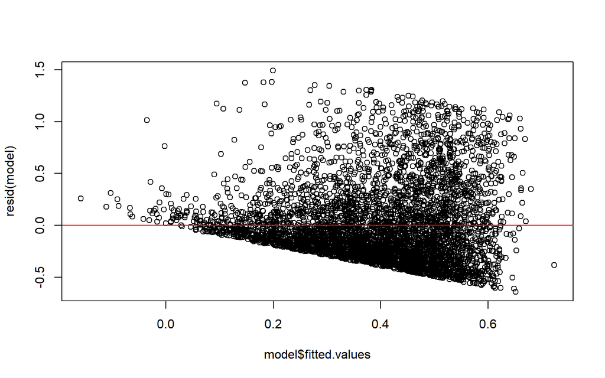

```r
plot(model$fitted.values, resid(model))
abline(h = 0, col = "red")
```

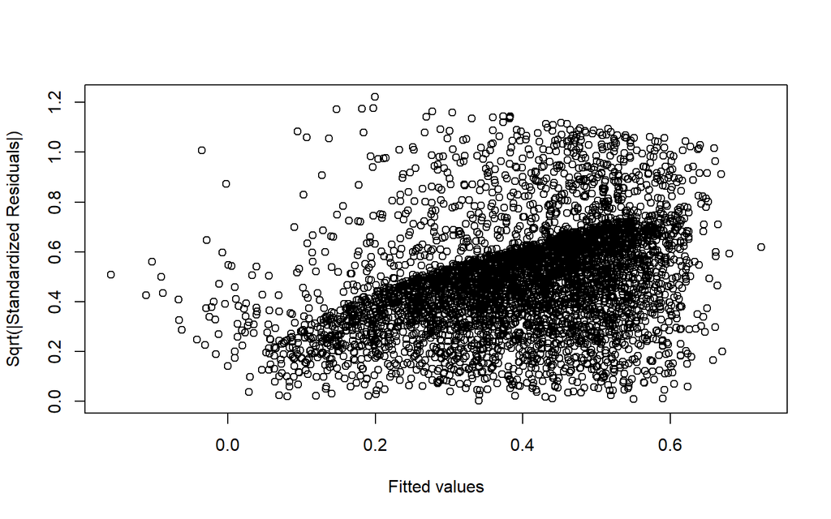

```r
plot(model$fitted.values, sqrt(abs(resid(model))),
     ylab = "Sqrt(|Standardized Residuals|)", xlab = "Fitted values")
```

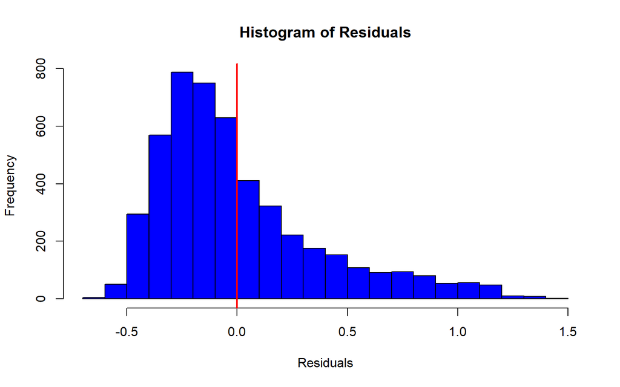

```r
residuals <- model$residuals
hist(residuals, breaks = 30, main = "Histogram of Residuals", xlab = "Residuals", col = "blue")
abline(v = mean(residuals), col = "red", lwd = 2)
```

## 4.2 The Classification problem

As we discovered, predicting the global sales as a numeric value is a challenging task due to the volatility and unpredictability of sales. While there are discernbale patterns on what makes a good game, the exact fluctuations in sales as a result of it are difficult to capture. Hence we move to a secondary approach.

**Classifying Games as Hit or Miss**

The second approach involves adding a columns called ‘Hit’ which classifies the game as a Hit or a Miss based on whether it lies in the top 25 percentile of games by global sales or not. This was decided based on the popularity of quantiles especially in boxplots in determining the upper echelon of video games.

### 4.2.1 Logistic Model

```r
# Load necessary libraries
library(dplyr)
library(caret)
```

```r
library(ggplot2)
library(reshape2)
# Assuming 'games_final' is your dataset
data <- games_final

# Define 'hit' games based on a threshold
hit_threshold <- quantile(data$Global_Sales, 0.75)
data$Hit <- ifelse(data$Global_Sales >= hit_threshold, 1, 0)
data$Hit <- as.factor(data$Hit)

# Function to bin categories
bin_categories <- function(column, top_n) {
  counts <- table(column)
  top_categories <- names(sort(counts, decreasing = TRUE)[1:top_n])
  column_binned <- ifelse(column %in% top_categories, column, "Others")
  return(column_binned)
}

# Bin 'Developer' category
data$Developer <- bin_categories(data$Developer, top_n = 10)

# Convert necessary variables to factors
data$Developer <- as.factor(data$Developer)
data$Platform <- as.factor(data$Platform)
data$Genre <- as.factor(data$Genre)
data$Year_of_Release <- as.numeric(as.character(data$Year_of_Release))

# Split data into training and testing sets
set.seed(123) # for reproducibility
index <- createDataPartition(data$Hit, p = 0.8, list = FALSE)
train_data <- data[index, ]
test_data <- data[-index, ]

# Fit a logistic regression model
logit_model <- glm(Hit ~ Critic_Score + Developer  + Genre ,
                   data = train_data, family = binomial())
print(summary(logit_model))
```

```
##
## Call:
## glm(formula = Hit ~ Critic_Score + Developer + Genre, family = binomial(),
##     data = train_data)
##
## Coefficients:
##                    Estimate Std. Error z value Pr(>|z|)
## (Intercept)       -4.639119   0.381704 -12.154  < 2e-16 ***
## Critic_Score       0.053450   0.003159  16.921  < 2e-16 ***
## Developer1553      0.309054   0.422558   0.731  0.46454
## Developer1561      0.390173   0.435695   0.896  0.37051
## Developer266      -0.145614   0.408228  -0.357  0.72132
## Developer307      -0.492524   0.489739  -1.006  0.31457
## Developer434      -0.130454   0.405546  -0.322  0.74770
## Developer452       0.556586   0.407152   1.367  0.17162
## Developer456       0.865595   0.435744   1.986  0.04698 *
## Developer480       0.516676   0.449320   1.150  0.25018
## Developer827      -0.289683   0.436706  -0.663  0.50712
## DeveloperOthers   -0.131287   0.329242  -0.399  0.69007
## GenreAdventure    -0.960955   0.242681  -3.960 7.50e-05 ***
## GenreFighting     -0.061046   0.160102  -0.381  0.70299
## GenreMisc          0.003359   0.161289   0.021  0.98338
## GenrePlatform      0.006520   0.158578   0.041  0.96720
## GenrePuzzle       -0.824972   0.318277  -2.592  0.00954 **
## GenreRacing       -0.135961   0.143275  -0.949  0.34265
## GenreRole-Playing -0.344525   0.129743  -2.655  0.00792 **
## GenreShooter       0.023498   0.118709   0.198  0.84309
## GenreSimulation   -0.325123   0.183257  -1.774  0.07604 .
## GenreSports       -0.210337   0.127580  -1.649  0.09922 .
## GenreStrategy     -1.142691   0.222714  -5.131 2.89e-07 ***
## ---
## Signif. codes:  0 '***' 0.001 '**' 0.01 '*' 0.05 '.' 0.1 ' ' 1
##
## (Dispersion parameter for binomial family taken to be 1)
##
##     Null deviance: 5558.4  on 4917  degrees of freedom
## Residual deviance: 5104.6  on 4895  degrees of freedom
## AIC: 5150.6
##
## Number of Fisher Scoring iterations: 4
```

```r
# Predict on test data
predictions <- predict(logit_model, newdata = test_data, type = "response")
predicted_class <- ifelse(predictions > 0.5, 1, 0)
predicted_class <- factor(predicted_class, levels = levels(test_data$Hit))

# Create a confusion matrix
conf_matrix <- confusionMatrix(predicted_class, test_data$Hit)

print(conf_matrix)
```

```
## Confusion Matrix and Statistics
##
##           Reference
## Prediction   0   1
##          0 897 273
##          1  21  37
##
##                Accuracy : 0.7606
##                  95% CI : (0.7357, 0.7842)
##     No Information Rate : 0.7476
##     P-Value [Acc > NIR] : 0.1542
##
##                   Kappa : 0.132
##
##  Mcnemar's Test P-Value : <2e-16
##
##             Sensitivity : 0.9771
##             Specificity : 0.1194
##          Pos Pred Value : 0.7667
##          Neg Pred Value : 0.6379
##              Prevalence : 0.7476
##          Detection Rate : 0.7305
##    Detection Prevalence : 0.9528
##       Balanced Accuracy : 0.5482
##
##        'Positive' Class : 0
##
```

```r
# Load necessary libraries
library(dplyr)
library(caret)
library(pROC)
```

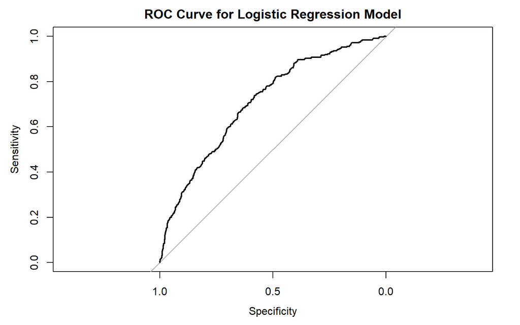

```r
# [Previous code for data preparation, logistic regression model training, and predictions]

# Calculate the ROC curve
roc_obj <- roc(test_data$Hit, as.numeric(predictions))
# Plot the ROC curve
plot(roc_obj, main = "ROC Curve for Logistic Regression Model")
```

```r
# Print AUC (Area Under the Curve)
auc(roc_obj)
```

```
## Area under the curve: 0.7107
```

```r
# Assuming you have 'predictions' and 'test_data$Hit' from your logistic regression model
predicted_class <- ifelse(predictions > 0.5, "1", "0")
predicted_class <- factor(predicted_class, levels = c("0", "1"))

# Actual values
actual_class <- test_data$Hit

# Create a table for Actual vs Predicted
confusion_matrix <- table(Predicted = predicted_class, Actual = actual_class)

# Print the confusion matrix
print(confusion_matrix)
```

```
##          Actual
## Predicted   0   1
##         0 897 273
##         1  21  37
```

We are using logistic regression model to predict if a games is hit or not based on the threshold value. we are using **Critic Score** , **Developer** and **Genre** as predicotrs. For making logistic model at first we are using binning function. Binning top developers because there are likely many unique developers in the dataset. Without binning, the model would have too many variables (one for each developer), many of which would have little data, leading to overfitting and making the model less generalizable. By binning, you reduce the complexity of the model and focus on the most common developers.

**Coefficients and p-values:** These values represent the change in the log odds of the dependent variable (in your case, whether a game is a ‘hit’ or not) for a one-unit change in the predictor.

**Critic_Score (Coefficient: 0.053450, p-value: < 2e-16)** * This is a highly significant predictor. The positive coefficient indicates that higher critic scores are associated with a higher likelihood of a game being a hit. The extremely low p-value suggests this relationship is statistically significant.

**Developer456 (Coefficient: 0.865595, p-value: 0.04698)**

- This specific developer (represented as ‘Developer456’) has a positive impact on the likelihood of a game being a hit. The p-value is just under 0.05, indicating that this result is statistically significant, although it’s on the borderline.

**GenreAdventure (Coefficient: -0.960955, p-value: 7.50e-05)**

- Being an adventure game is associated with a lower likelihood of being a hit, as indicated by the negative coefficient. The p-value is very small, showing strong evidence against the null hypothesis.

**GenrePuzzle (Coefficient: -0.824972, p-value: 0.00954)**

Puzzle games are also less likely to be hits. The negative coefficient and its low p-value signify a strong and statistically significant relationship.

**GenreRole-Playing (Coefficient: -0.344525, p-value: 0.00792)**

- Role-Playing games have a negative coefficient, suggesting they are less likely to be hits compared to the baseline genre. The p-value indicates this finding is statistically significant.

**GenreStrategy (Coefficient: -1.142691, p-value: 2.89e-07)**

- Strategy games show a strong negative association with being a hit. The coefficient is significantly negative, and the very low p-value strongly supports its significance.

**Null Devience:**

- Null deviance shows the goodness of fit of a model with no predictors (only the intercept) and residual deviance shows the goodness of fit of your model. A lower residual deviance compared to the null deviance indicates that the model is a better fit than the null model.

**Accuracy(0.7606):** * The above model has an accuracy of 76.06%, which means it correctly predicts whether a game is a hit or not 76.06% of the time.

```r
library(dplyr)
library(ggplot2)
games<-read.csv('Video games sales.csv')
str(games)
```

```
## 'data.frame':    16719 obs. of  16 variables:
##  $ Name           : chr  "Wii Sports" "Super Mario Bros." "Mario Kart Wii" "Wii Sports Resort" ...
##  $ Platform       : chr  "Wii" "NES" "Wii" "Wii" ...
##  $ Year_of_Release: chr  "2006" "1985" "2008" "2009" ...
##  $ Genre          : chr  "Sports" "Platform" "Racing" "Sports" ...
##  $ Publisher      : chr  "Nintendo" "Nintendo" "Nintendo" "Nintendo" ...
##  $ NA_Sales       : num  41.4 29.1 15.7 15.6 11.3 ...
##  $ EU_Sales       : num  28.96 3.58 12.76 10.93 8.89 ...
##  $ JP_Sales       : num  3.77 6.81 3.79 3.28 10.22 ...
##  $ Other_Sales    : num  8.45 0.77 3.29 2.95 1 0.58 2.88 2.84 2.24 0.47 ...
##  $ Global_Sales   : num  82.5 40.2 35.5 32.8 31.4 ...
##  $ Critic_Score   : int  76 NA 82 80 NA NA 89 58 87 NA ...
##  $ Critic_Count   : int  51 NA 73 73 NA NA 65 41 80 NA ...
##  $ User_Score     : num  8 NA 8.3 8 NA NA 8.5 6.6 8.4 NA ...
##  $ User_Count     : int  322 NA 709 192 NA NA 431 129 594 NA ...
##  $ Developer      : chr  "Nintendo" "" "Nintendo" "Nintendo" ...
##  $ Rating         : chr  "E" "" "E" "E" ...
```

```r
games$Platform<-as.factor(games$Platform)
games$Year_of_Release<-as.factor(games$Year_of_Release)
games$Genre<-as.factor(games$Genre)
games$Publisher<-as.factor(games$Publisher)
games$Developer<-as.factor(games$Developer)
games$Rating<-as.factor(games$Rating)
str(games)
```

```
## 'data.frame':    16719 obs. of  16 variables:
##  $ Name           : chr  "Wii Sports" "Super Mario Bros." "Mario Kart Wii" "Wii Sports Resort" ...
##  $ Platform       : Factor w/ 31 levels "2600","3DO","3DS",..: 26 12 26 26 6 6 5 26 26 12 ...
##  $ Year_of_Release: Factor w/ 40 levels "1980","1981",..: 27 6 29 30 17 10 27 27 30 5 ...
##  $ Genre          : Factor w/ 13 levels "","Action","Adventure",..: 12 6 8 12 9 7 6 5 6 10 ...
##  $ Publisher      : Factor w/ 583 levels "10TACLE Studios",..: 371 371 371 371 371 371 371 371 371 371 ...
##  $ NA_Sales       : num  41.4 29.1 15.7 15.6 11.3 ...
##  $ EU_Sales       : num  28.96 3.58 12.76 10.93 8.89 ...
##  $ JP_Sales       : num  3.77 6.81 3.79 3.28 10.22 ...
##  $ Other_Sales    : num  8.45 0.77 3.29 2.95 1 0.58 2.88 2.84 2.24 0.47 ...
##  $ Global_Sales   : num  82.5 40.2 35.5 32.8 31.4 ...
##  $ Critic_Score   : int  76 NA 82 80 NA NA 89 58 87 NA ...
##  $ Critic_Count   : int  51 NA 73 73 NA NA 65 41 80 NA ...
##  $ User_Score     : num  8 NA 8.3 8 NA NA 8.5 6.6 8.4 NA ...
##  $ User_Count     : int  322 NA 709 192 NA NA 431 129 594 NA ...
##  $ Developer      : Factor w/ 1697 levels "","10tacle Studios",..: 1035 1 1035 1035 1 1 1035 1035 1035 1 ...
##  $ Rating         : Factor w/ 9 levels "","AO","E","E10+",..: 3 1 3 3 1 1 3 3 3 1 ...
```

```r
games<-na.omit(games)
unique(games$Rating)
```

```
## [1] E    M    T    E10+      AO   K-A  RP
## Levels:  AO E E10+ EC K-A M RP T
```

```r
games$Rating <- ifelse( games$Rating== "", NA,games$Rating )
unique(games$Rating)
```

```
## [1]  3  7  9  4 NA  2  6  8
```

```r
games<-subset(games,games$Rating!="NA")
games<-subset(games,games$Year_of_Release!="N/A")
nrow(games)
```

```
## [1] 6826
```

```r
library(ezids)
games_final= outlierKD2(games,Global_Sales,rm=TRUE,hist=FALSE)
```

```
## Outliers successfully removed
```

```r
games_final<-na.omit(games_final)
```

## 4.3 References

-Chen, H., & Hu, Y. (2020). The impact of marketing campaigns on video game sales: A meta-analysis. Journal of Marketing, 84(4), 124-143. https://www.sciencedirect.com/science/article/pii/S0148296320304161

-Lin, Y., & Wu, C. (2021). The impact of player demographics on video game sales: A segmentation analysis. Computers in Human Behavior, 118, 106653. https://www.researchgate.net/publication/31977403_Segmentation_of_the_games_market_using_multivariate_analysis

-Duan, W., & Zhang, J. (2019). The impact of critic reviews on video game sales: Evidence from a large-scale panel dataset. Journal of Business Research, 104, 70-80. https://pubsonline.informs.org/doi/abs/10.1287/mnsc.2023.4754

-[OIS] Diez et al. (2015), OpenIntro Statistics. https://leanpub.com/os